# MSIS 510 Logistic Regression Tutorial

## Logistic Regression

Logistic regression is a method for fitting a regression curve, $y = f(x)$, when $y$ is a `binary` variable. The typical use of this model is predicting `y` given a set of predictors `x`. The predictors can be continuous, categorical or a mix of both.

### How does Logistic Regression work?

1. Calculate probability
2. Classify each example by comparing the predicted probability to a cutoff probability

#### Step 1: Calculate Probability

For Linear Regression, where the output is a linear combination of input feature(s), we write the equation as:
$$\begin{equation}
Y = \beta_0 + \beta_1x_1 +\beta_2x_2 + \beta_2x_2 + \dots + \beta_px_p
\end{equation}$$
If Y is a binary variable, we cannot use the above formula directly. Why?

Instead of predicting $Y$ directly, we predict the $P(Y = 1|X)$ in logistic regression, the **probability** of $Y$ being 1 given the feature $X$.

To make sure the output is **indeed** a probability, we need to make sure the outcome meets two criteria.

- The Y must be positive (greater than 0).
- It should be lower than 1.

We then can make the following transformations.

$$p={1 \over {1 + {e^{-(\beta_0 + \beta_1x_1 +\beta_2x_2 + \beta_2x_2 + \dots + \beta_px_p)}}}}$$
We can write the function in a genral form. We call it losgixtic response functin
$$f(z) = {1 \over {1 + e^{-z}}}$$

#### Step 2: Classify each example using by comparing the predicted probability to a cutoff probability

- If $\hat p \le p_{cutoff}$, then $y=0$
- If $\hat p > p_{cutoff}$, then $y=1$

## Today’s Outline:

1. Demo: Flight delays
2. Practice: Acceptance of Personal Loan

## Demo: Flight Delays

Predicting flight delays can be useful to a variety of organizations: airport authorities, airlines, aviation authorities. At times, joint task forces have been formed to address the problem. Such an organization, if it were to provide ongoing real-time assistance with flight delays, would benefit from some advance notice about flights likely to be delayed.

Main goals:

1. Find a model that can obtain accurate delay predictions of new flights.
2. Find a certain percentage of flights that are most/least likely to get delayed (ranking).
3. Find out which factors are associated with a delay.

### Data Description

| DAY_WEEK | CRS_DEP_TIME | ORIGIN | DEST | CARRIER | Weather | Flight.Status |
| --- | --- | --- | --- | --- | --- | --- |
| 4 | 2120 | IAD | LGA | DH | 0 | ontime |
| 3 | 2120 | IAD | JFK | DH | 0 | ontime |
| 5 | 1455 | BWI | EWR | RU | 0 | ontime |
| 5 | 1720 | BWI | EWR | RU | 0 | ontime |
| 5 | 600 | DCA | JFK | MQ | 0 | ontime |
| 3 | 1830 | DCA | JFK | MQ | 0 | delayed |

### Step 1: Read data

```r
# read data
delays.df <- read.csv("FlightDelays.csv", stringsAsFactors = TRUE)
```

Let’s check out what kinds of variables we have

```r
str(delays.df)
```

```
## 'data.frame':    2000 obs. of  13 variables:
##  $ CRS_DEP_TIME : int  2120 2120 1455 1720 600 1830 1245 730 2120 2000 ...
##  $ CARRIER      : Factor w/ 8 levels "CO","DH","DL",..: 2 2 6 6 4 4 2 3 2 8 ...
##  $ DEP_TIME     : int  2114 2119 1456 1726 553 1918 1251 733 2126 2001 ...
##  $ DEST         : Factor w/ 3 levels "EWR","JFK","LGA": 3 2 1 1 2 2 3 3 2 3 ...
##  $ DISTANCE     : int  229 228 169 169 213 213 229 214 228 214 ...
##  $ FL_DATE      : Factor w/ 31 levels "1/1/04","1/10/04",..: 1 6 12 16 8 29 18 4 2 22 ...
##  $ FL_NUM       : int  7924 7814 2403 3372 4760 4784 7208 1742 7814 2186 ...
##  $ ORIGIN       : Factor w/ 3 levels "BWI","DCA","IAD": 3 3 1 1 2 2 3 2 3 2 ...
##  $ Weather      : int  0 0 0 0 0 0 0 0 0 0 ...
##  $ DAY_WEEK     : int  4 3 5 5 5 3 7 1 6 4 ...
##  $ DAY_OF_MONTH : int  1 14 2 23 16 7 25 12 10 29 ...
##  $ TAIL_NUM     : Factor w/ 528 levels "N10323","N10575",..: 319 301 38 188 396 486 321 192 317 418 ...
##  $ Flight.Status: Factor w/ 2 levels "delayed","ontime": 2 2 2 2 2 1 2 2 2 2 ...
```

We cannot use `DAY_WEEK` directly because the class of DAY_WEEK is the **integer**.

Why? (Hint: Consider how we interpret the coefficients)

What about `CRS_DEP_TIME` (scheduled local departure time)?

### Step 2: Preprocess the data

#### Create Categorical Variables

- `DAY_WEEK` is coded as 1 = Monday, 2 = Tuesday, … , 7 = Sunday. We want to transform day of week into a categorical variable.
- `CRS_DEP_TIME` is coded as a 4-digit number. (e.g. 1432 = 2:32 PM). We want to bin and categorize the departure time into hourly intervals between 6 AM and 10 PM.

First, we re-code the `DAY_WEEK` into categorical data.

```r
# transform to a factor
delays.df$DAY_WEEK <- factor(delays.df$DAY_WEEK)
```

To make the values more descriptive, we next re-name it to Mon, Tue,… We can first examine the levels of `delays.df$DAY_WEEK` and then re-name each of the levels.

```r
levels(delays.df$DAY_WEEK)
```

```
## [1] "1" "2" "3" "4" "5" "6" "7"
```

```r
# rename the levels in order
levels(delays.df$DAY_WEEK) <- c("Mon", "Tue", "Wed", "Thu", "Fri", "Sat", "Sun")
```

Next, we want to bin and categorize `CRS_DEP_TIME` into hourly intervals between 6 AM and 10 PM. Since `CRS_DEP_TIME` is a number with the form `1430`, we take the hour part by division and rounding.

```r
delays.df$CRS_DEP_TIME <- factor(round(delays.df$CRS_DEP_TIME/100))
```

#### Set base level for categorical variables (Optional).

We can set **base level** for the categorial variables. For a categorical variable with $n$ levels, we can only get the coefficients for the $n −1$ levels except the base level. The coefficients for categorical variables are interpreted as how the **current level** influence the dependent variable compared to the **base level**.

We will use the The `relevel` function. Levels of a factor are re-ordered so that the level specified by `ref` is first and the others are moved down.

```r
# create reference category or base level
delays.df$ORIGIN <- relevel(delays.df$ORIGIN, ref = "IAD")
delays.df$DEST <- relevel(delays.df$DEST, ref = "LGA")
delays.df$CARRIER <- relevel(delays.df$CARRIER, ref = "US")
delays.df$DAY_WEEK <- relevel(delays.df$DAY_WEEK, ref = "Mon")
```

#### Re-code the target variable to indicate which target value is associated with Class 1.

Let’s also recode the target variable (`Flight.Status`) to make sure that we know which status is associated with 1. We can use `as.numeric` to transform logical values into compatible numeric values.

```r
delays.df$Flight.Status <- as.numeric(delays.df$Flight.Status == "delayed")
```

### Step 3: Partition data

Now we are ready to generate train and validation set. `selected.var` contains the column numbers of six predictors we use.

```r
# create training and validation sets
set.seed(5)
# select variables
selected.var <- c(10, 1, 8, 4, 2, 9, 13)
selected.df <- delays.df[, selected.var]
# partition the data
train.index <- sample(1:nrow(delays.df), nrow(delays.df)*0.6)
train.df <- selected.df[train.index, ]
valid.df <- selected.df[-train.index, ]
```

### Step 4: Fit a logistic regression model

The function `glm` is for generalized linear models (logistic regression is one of the generalized linear models). We specify that the outcome is binary by setting `family = "binomial"`.

```r
# run logistic model, and show coefficients
logit.reg <- glm(Flight.Status ~ ., data = train.df, family = "binomial")
summary(logit.reg)
```

```
##
## Call:
## glm(formula = Flight.Status ~ ., family = "binomial", data = train.df)
##
## Deviance Residuals:
##     Min       1Q   Median       3Q      Max
## -1.4127  -0.6743  -0.5042  -0.2508   2.8376
##
## Coefficients:
##                 Estimate Std. Error z value Pr(>|z|)
## (Intercept)     -2.16365    0.65819  -3.287 0.001012 **
## DAY_WEEKTue     -0.59946    0.29608  -2.025 0.042902 *
## DAY_WEEKWed     -0.63494    0.28563  -2.223 0.026220 *
## DAY_WEEKThu     -0.67786    0.27298  -2.483 0.013021 *
## DAY_WEEKFri     -0.50902    0.26947  -1.889 0.058897 .
## DAY_WEEKSat     -1.17263    0.33932  -3.456 0.000549 ***
## DAY_WEEKSun     -0.22966    0.29102  -0.789 0.430020
## CRS_DEP_TIME7    0.16826    0.54669   0.308 0.758255
## CRS_DEP_TIME8    0.19564    0.55082   0.355 0.722450
## CRS_DEP_TIME9   -1.96990    1.09628  -1.797 0.072353 .
## CRS_DEP_TIME10  -0.01869    0.62965  -0.030 0.976314
## CRS_DEP_TIME11  -0.05234    0.69413  -0.075 0.939896
## CRS_DEP_TIME12   0.33584    0.53851   0.624 0.532864
## CRS_DEP_TIME13  -0.26137    0.58208  -0.449 0.653406
## CRS_DEP_TIME14   0.47122    0.53134   0.887 0.375159
## CRS_DEP_TIME15   1.23850    0.46103   2.686 0.007223 **
## CRS_DEP_TIME16   0.66517    0.49767   1.337 0.181362
## CRS_DEP_TIME17   0.97217    0.47101   2.064 0.039018 *
## CRS_DEP_TIME18   0.44524    0.62244   0.715 0.474414
## CRS_DEP_TIME19   1.40346    0.51685   2.715 0.006619 **
## CRS_DEP_TIME20   0.81922    0.65948   1.242 0.214155
## CRS_DEP_TIME21   1.18140    0.48819   2.420 0.015521 *
## ORIGINBWI        0.37984    0.40477   0.938 0.348037
## ORIGINDCA       -0.30201    0.37288  -0.810 0.417975
## DESTEWR         -0.34694    0.37472  -0.926 0.354507
## DESTJFK         -0.29836    0.26956  -1.107 0.268370
## CARRIERCO        1.78206    0.57618   3.093 0.001982 **
## CARRIERDH        1.06190    0.51814   2.049 0.040420 *
## CARRIERDL        0.54541    0.33072   1.649 0.099118 .
## CARRIERMQ        1.60016    0.33525   4.773 1.81e-06 ***
## CARRIEROH       -1.04479    1.18955  -0.878 0.379778
## CARRIERRU        1.18139    0.52824   2.236 0.025320 *
## CARRIERUA        0.92224    0.86217   1.070 0.284768
## Weather         16.79013  358.88048   0.047 0.962685
## ---
## Signif. codes:  0 '***' 0.001 '**' 0.01 '*' 0.05 '.' 0.1 ' ' 1
##
## (Dispersion parameter for binomial family taken to be 1)
##
##     Null deviance: 1209.2  on 1199  degrees of freedom
## Residual deviance: 1037.4  on 1166  degrees of freedom
## AIC: 1105.4
##
## Number of Fisher Scoring iterations: 14
```

How do you interpret the result?

$$log(Odds) = log({p \over {1-p}}) =\beta_0 + \beta_1x_1 +\beta_2x_2 + \beta_2x_2 + \dots + \beta_px_p$$

### Step 5: Generate outcome by comparing predicted probability with the cutoff probability

First calculate the predicted probability of belonging to class 1 on validation set.

```r
# use predict() with type = "response" to compute predicted probabilities
# if type not specified, log-odds will be returned
logit.reg.pred <- predict(logit.reg, valid.df,  type = "response")
```

#### Base case: cutoff = 0.5

- If $\hat p \le 0.5$, then $y=0$
- If $\hat p > 0.5$, then $y=1$

We can use `ifelse` function to generate outcome.

- usage: ifelse(test, yes, no)
- test: a logical statement
- yes: the return value if the answer is yes
- no: the return value if the anser is no

```r
# Choose cutoff value and evaluate classification performance
pred <- ifelse(logit.reg.pred > 0.5, 1, 0)
```

Calculate the prediction accuracy using confusion matrix. In order to compute sensitivity and specificity, we need to specify which class is the important class, by using `positive = "1"`.

```r
## generate the confusion matrix based on the prediction
library(caret)
confusionMatrix(factor(pred), factor(valid.df$Flight.Status), positive = "1")
```

```
## Confusion Matrix and Statistics
##
##           Reference
## Prediction   0   1
##          0 650 120
##          1  10  20
##
##                Accuracy : 0.8375
##                  95% CI : (0.8101, 0.8624)
##     No Information Rate : 0.825
##     P-Value [Acc > NIR] : 0.1889
##
##                   Kappa : 0.185
##
##  Mcnemar's Test P-Value : <2e-16
##
##             Sensitivity : 0.1429
##             Specificity : 0.9848
##          Pos Pred Value : 0.6667
##          Neg Pred Value : 0.8442
##              Prevalence : 0.1750
##          Detection Rate : 0.0250
##    Detection Prevalence : 0.0375
##       Balanced Accuracy : 0.5639
##
##        'Positive' Class : 1
##
```

#### Change the cutoff value to 0.2

```r
# set the cutoff to be 0.2 and evaluate the model
pred <- ifelse(logit.reg.pred > 0.2, 1, 0)
confusionMatrix(factor(pred), factor(valid.df$Flight.Status), positive = "1")
```

```
## Confusion Matrix and Statistics
##
##           Reference
## Prediction   0   1
##          0 423  54
##          1 237  86
##
##                Accuracy : 0.6362
##                  95% CI : (0.6018, 0.6697)
##     No Information Rate : 0.825
##     P-Value [Acc > NIR] : 1
##
##                   Kappa : 0.1685
##
##  Mcnemar's Test P-Value : <2e-16
##
##             Sensitivity : 0.6143
##             Specificity : 0.6409
##          Pos Pred Value : 0.2663
##          Neg Pred Value : 0.8868
##              Prevalence : 0.1750
##          Detection Rate : 0.1075
##    Detection Prevalence : 0.4037
##       Balanced Accuracy : 0.6276
##
##        'Positive' Class : 1
##
```

Which one is more accurate?

#### Step 6: Generate ROC curve

```r
library(pROC)
r <- roc(valid.df$Flight.Status, logit.reg.pred)
```

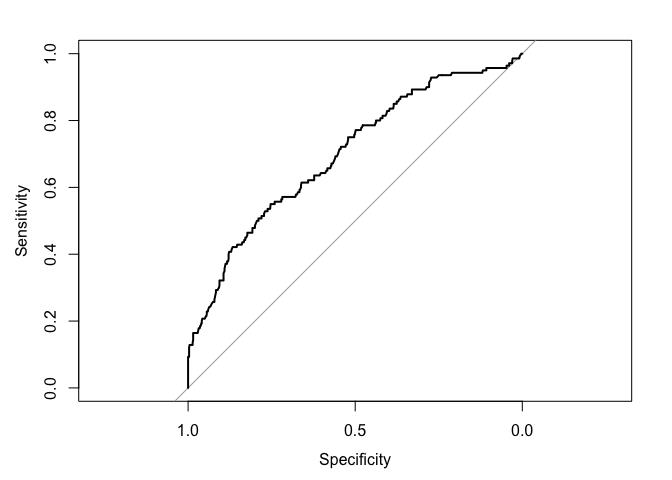

```r
plot.roc(r)
```

There are multiple criteria to find the “optimal” threshold, for example: the optimal cut-off is the threshold that maximizes the distance to the identity (diagonal) line.The optimality criterion is:

$$max(sensitivities + specificities)$$
There are other criteria as well, see `?coords` for more information.

```r
# find the best threshold
coords(r, x = "best", transpose = FALSE)
```

```
##   threshold specificity sensitivity
## 1 0.2466329   0.7530303        0.55
```

You can also examine the specificity and sensitivity of the thresholds that are of interests, and choose the one to use.

```r
coords(r, x = c(0.1, 0.2, 0.5),  transpose = FALSE)
```

```
##   threshold specificity sensitivity
## 1       0.1   0.3181818   0.8928571
## 2       0.2   0.6409091   0.6142857
## 3       0.5   0.9848485   0.1428571
```

## Practice: Acceptance of Personal Loan

Universal Bank is a relatively young bank that is growing rapidly in terms of overall customer acquisition. The bank wants to explore ways of converting its liability (deposit) customers to personal loan customers.

### Data Description

The bank’s dataset includes data on 5000 customers. The data include customer demographic information (age, income, etc), customer response to the last personal loan campaign (Personal Loan), and the customer’s relationship with the bank (mortgage, securities account, etc.). Among these 5000 customers only 480 (= 9.6%) accepted the personal loan that was offered to them in the earlier campaign. In the target column, 1 means the customer accepted the loan.

### Questions

1. Preprocess Education, which is a categorical variable
   - use `factor` to factor the variable and rename the levels to proper names:
     - 1: Undergrad
     - 2: Graduate
     - 3: Advanced/Professional
   - use relevel to set up the base level to “Advanced/Professional”
2. Partition the data into 80% training vs. 20% validation with the seed set to 2
3. Run logistic regression.
   - use `glm` (general linear model) with family = “binomial” to fit a logistic regression
4. Set the cutoff to be 0.5 and find out the prediction accuracy on the validation set. What is the sensitivity and specificity (make sure to set up the importance case when compute the confusion matrix).
5. In the validation data, among those who accepted the personal loan, what is the percentage of customers classified as declining the loan?
6. To decrease the percentage in the previous question, should the cutoff value be increased or decreased?